# The Age Structure of the Electorate, 1966–2024

Who is old enough to vote, who says they voted, and sixty years of the gap between the two

Democracy’s Data

Last updated September 13, 2026 at 10:53a EDT

Older Americans run American elections. You have heard the sentence, or one of its relatives: the electorate is grey, the young do not vote, politicians answer to the people who show up. It is repeated as though it were a permanent fact about the country. Is it true — and if it is, how much more do older Americans actually vote, and has the gap always been there?

Start with a distinction the word “electorate” hides. It sometimes means everybody entitled to vote, and it sometimes means everybody who did. Those are different populations. In 2024, **260.4m** Americans were old enough to vote and **154.4m** told the Census Bureau they had — 59.3%. The clearest way to see how different the two groups are is to draw them as two pyramids on one axis, and to watch the pyramids for sixty years.

## The test

The data is the Census Bureau’s [Current Population Survey, Voting and Registration Supplement](https://www2.census.gov/programs-surveys/cps/tables/time-series/voting-historical-time-series/hst_vote01.xlsx) — historical Table A-1, whose age blocks cover 30 federal elections from 1966 to 2024. The Current Population Survey is the Bureau’s monthly survey of households, best known as the source of the unemployment rate. After every federal election since 1964, it has asked the roughly 60,000 households in that month’s sample whether the adults in them voted, and the Bureau publishes what they said, by age.[^1]

Be clear about what kind of source that is. The same Bureau runs the decennial census, which is an enumeration: an attempt to count everyone, one by one. The CPS is the other instrument: a survey, a sample of households chosen to stand in for the country. Its answers are weighted, which means counting some responses more than others so the sample matches the population.

Nobody’s voting answer is checked against a record; every “voted” in this brief is a self-report — a person’s own account, taken at its word. This brief sits in the survey section because that is what the source is, whoever publishes it. The surveys chapter lays out what a sample can establish that a count cannot, and this series is a sixty-year example.

Why this source, of all sources? Because nothing else reaches. No administrative record pairs a national age profile of the adult population with an age profile of its voters, election after election, back to the 1960s. The CPS supplement does exactly that, in one continuously published table, from the agency that also measures the population itself.

## The data

The workbook is not one table. It is ten tables stacked in a single spreadsheet column: five age groups (the total, then four bands), each appearing twice, once for voting and once for registration. Pulled apart and reassembled, those ten blocks become two flat files.

`bands.csv` holds one row per year per age band:

| Column | What it holds | Measurement |
| --- | --- | --- |
| year | the federal election year, 1966 to 2024 | discrete |
| band | one of the Bureau’s four age bands | ordered categorical |
| vap | voting-age population, in thousands | count |
| pct_voted | the share who told the survey they voted | continuous |
| voters | vap multiplied by that share — a count this chapter derives | count |

The Bureau publishes the population and the percentage; the count of voters is the two multiplied, which is arithmetic on its own figures rather than an estimate of ours. Here is 2024:

| Age band | Old enough to vote | Said they voted | Turnout | Registered |
| --- | --- | --- | --- | --- |
| 18–24 | 30.0m | 13.2m | 43.9% | 53.5% |
| 25–44 | 88.8m | 46.5m | 52.4% | 61.5% |
| 45–64 | 81.2m | 51.3m | 63.2% | 69.8% |
| 65+ | 60.4m | 43.3m | 71.7% | 77.1% |

`shares.csv` is derived from it: each band’s `pop_share` of everybody old enough to vote, its `vote_share` of everybody who said they voted, and `gap`, the second minus the first. The four bands are published separately from the total, so they can be checked against it:

| Check | Value |
| --- | --- |
| age blocks found | 10 |
| years covered | 30 |
| largest gap, bands against total (population) | 0.001% |
| largest gap, bands against total (voters) | 0.207% |

> **Before you read on, commit to a view.** People aged 65 and over are 23.2% of American adults. **What share of the votes do you think they cast?** Write it down, and write down what you would have guessed for 1968.

## What it says about democracy

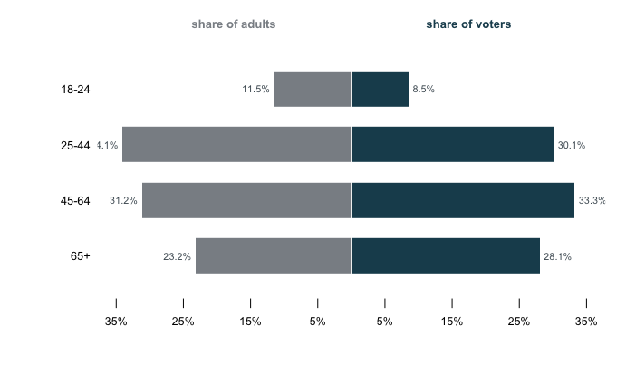

**Figure 1. The adult population and the voters, 2024.** Two pyramids on one axis, because the question is whether the second population is a scale model of the first, and a pyramid shows the answer band by band. Grey to the left is each band’s share of everybody old enough to vote; teal to the right is its share of everybody who said they voted. Drag the year; the button switches from shares to counts of people.

The two sides are not the same shape. **People aged 65 and over are 23.2% of the adult population and 28.1% of the voters.** People aged 18 to 24 are 11.5% of adults and 8.5% of voters. Compare that with what you wrote down.

So the claim survives its first test. The people who show up are older than the country that could have shown up, by a margin large enough to see from across the room. The second question is whether it was always so, and the answer is the finding of this brief.

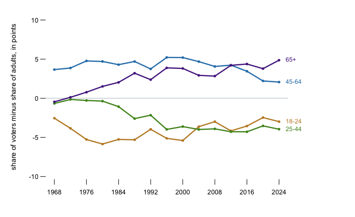

**Figure 2. Over-representation, presidential elections 1968 to 2024.** One line per band: its share of the voters minus its share of the adults, so zero means a band cast exactly its share of the votes. A line, rather than more pyramids, because the question here is change over time.

The oldest band starts at **-0.5** in 1968, meaning it voted almost exactly in proportion to its size. It ends at **+4.9**. The over-representation of older voters is not an old feature of American elections. It is roughly as old as the people currently complaining about it.

Two things drove it and they are easy to confuse. The band grew: 65-and-over went from 15.8% of adults in 1968 to 23.2% now, which is demography and would have raised their share of the votes even if nothing about their behaviour had changed. And on top of that their turnout advantage widened. **The first is a fact about the country. The second is a fact about its politics.** A count of votes cast cannot separate them, which is why Figure 2 is drawn as a difference between two shares.

## What this brief cannot tell you

**These are people who said they voted.** The survey asks after the election, and nobody checks. The validated-turnout chapter establishes that the answer is consistently too high — in 2024 the survey implies more voters than there were ballots. If over-reporting differs by age, and there is good reason to think it does,[^2] then the right-hand pyramid is distorted in a way none of these figures can correct.

**Four bands is a coarse pyramid.** A conventional population pyramid has five-year bands and splits by sex; this one has four unequal bands and no sex, because that is what the historical table publishes. The 25-to-44 band spans twenty years and the 65-and-over band has no upper bound, so both hide structure — the oldest band in particular mixes people at very different turnout rates. And the youngest band changes its meaning once. Before 1972 the voting age was 21 in most states, so the youngest block for the earlier elections counts mostly 21-to-24-year-olds; the Twenty-sixth Amendment, ratified in 1971, lowered the age to 18 everywhere,[^3] and the band’s population jumps from 11.6m in 1968 to 24.6m in 1972 for that reason. Figure 2’s first point for that band describes a narrower group than its label.

**Nothing here is about a state.** These are national figures. The turnout-denominator chapter shows how much states differ on the denominator alone, the bottom number a turnout rate is divided by. An age pyramid for Florida would not look like one for Utah.

**Being over-represented is not the same as being decisive.** A band that casts 28.1% of the votes decides nothing on its own, and this brief has said nothing about how any band voted. Who shows up is prior to, and separate from, what they do when they get there.

## Sources

**Data**

- U.S. Census Bureau. *Current Population Survey, Voting and Registration Supplement*, Table A-1, historical time series, November 1964 to 2024. https://www2.census.gov/programs-surveys/cps/tables/time-series/voting-historical-time-series/hst_vote01.xlsx
- The same workbook is read for its national totals by this book’s validated-turnout chapter, which documents what the table does and does not publish. The four age blocks further down the same sheet are read here, and checked to see that they reconstruct the published total.
- U.S. Census Bureau. “About the Current Population Survey.” https://www.census.gov/programs-surveys/cps/about.html
- Ansolabehere, Stephen, and Eitan Hersh (2012). “Validation: What Big Data Reveal About Survey Misreporting and the Real Electorate.” *Political Analysis* 20(4): 437–459. https://doi.org/10.1093/pan/mps023

**The data itself**

Every figure above is drawn from these tables. They are plain CSV, they open in a spreadsheet, and they are yours to take further.

`bands.csv`, `shares.csv`

Two more files here are not data about the subject at all – they are how this chapter checked its own work: `facts.csv`, the individual numbers the text above quotes, and `checks.csv`, the arithmetic verified before anything was drawn.

Rebuild this data yourself, with an AI assistant

```
I want to rebuild a public dataset from its original source, without any
starting files. Please do the following and show your work.

THE SOURCE. U.S. Census Bureau, Current Population Survey, Voting and
Registration Supplement, historical Table A-1. One spreadsheet at
https://www2.census.gov/programs-surveys/cps/tables/time-series/voting-historical-time-series/hst_vote01.xlsx
No account or key is needed. The sheet is not one table: it is ten
tables stacked in a single column. Five age groups -- the total, then
18 to 24, 25 to 44, 45 to 64, and 65 and over -- each appear twice,
once under a heading ending "Percent Voted" and once under "Percent
Registered". Find those headings and read years downward until the
years stop. Populations are in thousands. And keep in mind what this
is: a survey that asks people after the election whether they voted,
and nobody checks. People say yes more often than they voted.

WHAT TO BUILD.
1. One table with a row per election year per age group: the
   voting-age population, the percent who said they voted, and the
   count of voters that implies.
2. Each group's share of all adults beside its share of everyone who
   said they voted, year by year -- two age pyramids, one of the
   population and one of the reported electorate.

CHECK YOUR WORK. The copy this book used was downloaded in August 2026.
If your rebuild matches it, you should find:
- ten stacked tables, together covering 30 federal elections from
  1966 through 2024
- in 2024, an adult population of 260,363 thousand, of whom 154,395
  thousand said they voted
- in 2024, 43.9% of 18-to-24-year-olds said they voted, against
  71.7% of people 65 and over
- the four age groups reconstruct the published total to within
  0.207%
The Bureau extends this workbook after each federal election; a later
final year means the series grew, not that you made an error.
```

[^1]: U.S. Census Bureau, “About the Current Population Survey,” https://www.census.gov/programs-surveys/cps/about.html, and the voting supplement’s own page, https://www.census.gov/topics/public-sector/voting/about.html.
[^2]: When survey answers are matched against the official record of who voted, the people who claim a vote they did not cast turn out to resemble actual voters — more educated, more partisan, more engaged — so the over-report is not spread evenly across groups. Stephen Ansolabehere and Eitan Hersh, “Validation: What Big Data Reveal About Survey Misreporting and the Real Electorate,” *Political Analysis* 20, no. 4 (2012): 437–459, https://doi.org/10.1093/pan/mps023.
[^3]: U.S. Const. amend. XXVI, text at https://www.law.cornell.edu/constitution/amendmentxxvi.